# Comparing Case-Crossover and Poisson GLM Approaches

Analysis of Ozone Effects on Cardiovascular Disease Deaths

Time Series Analysis Demonstration

2025-05-30

## Introduction

This document demonstrates how the same time series dataset can be analyzed using two different statistical approaches:

1. **Case-Crossover Analysis** - A self-matched case-control design
2. **Poisson GLM** - Generalized linear modeling for count data

Both methods are commonly used in environmental epidemiology to study the short-term effects of air pollution on health outcomes.

I have used codes from https://doi.org/10.32614/CRAN.package.season and conduct a similar experiment to

```
Lu, Y., Symons, J.M., Geyh, A.S. and Zeger, S.L. (2008)
‘An Approach to Checking Case-Crossover Analyses Based on Equivalence With Time-Series Methods’,
Epidemiology, 19(2), pp. 169–175. Available at: https://doi.org/10.1097/EDE.0b013e3181632c24.
```

**NOTE**: this code uses aggregated count data, but case-crossover can be run with individual-level data, and that’s actually the more common and natural format for case-crossover studies.

## Data Setup

```r
# Load required libraries
library(season)  # for casecross function
library(splines) # for smooth functions in GLM
library(knitr)   # for nice tables
library(ggplot2) # for plotting
library(lubridate)
```

```r
# Load cardiovascular disease data
data(CVDdaily)

# Subset data for example (through 1987)
CVDdaily <- subset(CVDdaily, date <= as.Date('1987-12-31'))

# Display basic information about the dataset
cat("Dataset dimensions:", dim(CVDdaily), "\n")
```

```
## Dataset dimensions: 365 17
```

```r
cat("Date range:", as.character(range(CVDdaily$date)), "\n")
```

```
## Date range: 1987-01-01 1987-12-31
```

```r
cat("Total CVD deaths:", sum(CVDdaily$cvd), "\n")
```

```
## Total CVD deaths: 17567
```

```r
# Summary of key variables
summary(CVDdaily[, c("cvd", "o3mean", "tmpd")])
```

```
##       cvd            o3mean              tmpd
##  Min.   :26.00   Min.   :-23.4297   Min.   :44.75
##  1st Qu.:42.00   1st Qu.:-13.8024   1st Qu.:59.00
##  Median :47.00   Median : -1.2065   Median :65.25
##  Mean   :48.13   Mean   : -0.5132   Mean   :63.45
##  3rd Qu.:54.00   3rd Qu.: 11.9290   3rd Qu.:68.00
##  Max.   :82.00   Max.   : 33.8642   Max.   :86.00
```

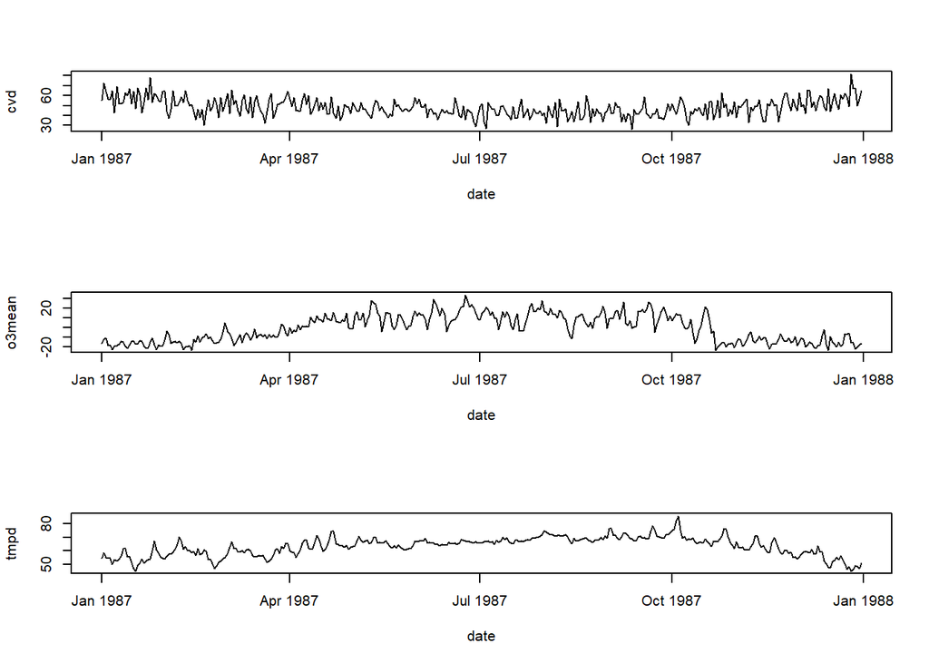

```r
par(mfrow=c(3,1))
with(CVDdaily, plot(date, cvd, type = 'l'))
with(CVDdaily, plot(date, o3mean, type = 'l'))
with(CVDdaily, plot(date, tmpd, type = 'l'))
```

## Case-Crossover Analysis

Case-crossover is a variant of the case-control design where each case serves as its own control. This eliminates confounding by time-invariant factors.

### Model 1: Case-Crossover with Day-of-Week Matching

```r
# NB casecross cannot handle  ns(tmpd, df = 3) directly so pre-created spline basis in the data setup
temp_spline <- ns(CVDdaily$tmpd, df = 3)
colnames(temp_spline) <- paste0("temp_spline_", 1:3)
CVDdaily <- cbind(CVDdaily, temp_spline)

# Match on day of the week automatically
model1 <- casecross(cvd ~ o3mean + temp_spline_1 + temp_spline_2 + temp_spline_3,
                    matchdow = TRUE,
                    data = CVDdaily)
summary(model1)
```

```
## Time-stratified case-crossover with a stratum length of 28 days
## Matched on day of the week
## Total number of cases 17502
## Number of case days with available control days 364
## Average number of control days per case day 3
##
## Parameter Estimates:
##                       coef exp(coef)    se(coef)           z    Pr(>|z|)
## o3mean        -0.003467577 0.9965384 0.001207336 -2.87208940 0.004077676
## temp_spline_1 -0.003128251 0.9968766 0.065392671 -0.04783794 0.961845399
## temp_spline_2 -0.134108626 0.8744951 0.123830148 -1.08300464 0.278806362
## temp_spline_3  0.070283619 1.0728124 0.108270766  0.64914678 0.516243507
```

**Interpretation:** The `matchdow=TRUE` option automatically matches cases and controls on the same day of the week.

## Poisson GLM Analysis

Now let’s analyze the same data using Poisson regression, which is appropriate for count data like daily death counts.

### Model 2: Poisson GLM with Temperature Spline

```r
n_year <- length(unique(year(CVDdaily$date)))
df_to_use <- n_year * 7
# Use smooth function for temperature instead of linear term
poisson1 <- glm(cvd ~ o3mean + ns(tmpd, df = 3) + Mon + Tue + Wed + Thu + Fri + Sat +
                ns(date, df = df_to_use),
                data = CVDdaily,
                family = poisson())

summary(poisson1)
```

```
##
## Call:
## glm(formula = cvd ~ o3mean + ns(tmpd, df = 3) + Mon + Tue + Wed +
##     Thu + Fri + Sat + ns(date, df = df_to_use), family = poisson(),
##     data = CVDdaily)
##
## Coefficients:
##                            Estimate Std. Error z value Pr(>|z|)
## (Intercept)                4.103622   0.059483  68.988  < 2e-16 ***
## o3mean                    -0.002628   0.001141  -2.302 0.021329 *
## ns(tmpd, df = 3)1          0.084186   0.059443   1.416 0.156706
## ns(tmpd, df = 3)2         -0.008459   0.126428  -0.067 0.946657
## ns(tmpd, df = 3)3          0.143692   0.100365   1.432 0.152229
## Mon                        0.046069   0.028935   1.592 0.111351
## Tue                        0.067430   0.028823   2.339 0.019312 *
## Wed                        0.006795   0.029245   0.232 0.816268
## Thu                        0.007797   0.029307   0.266 0.790214
## Fri                        0.047594   0.029092   1.636 0.101848
## Sat                        0.005877   0.028861   0.204 0.838629
## ns(date, df = df_to_use)1 -0.163867   0.057775  -2.836 0.004564 **
## ns(date, df = df_to_use)2 -0.290264   0.076494  -3.795 0.000148 ***
## ns(date, df = df_to_use)3 -0.369083   0.068855  -5.360 8.31e-08 ***
## ns(date, df = df_to_use)4 -0.378503   0.079901  -4.737 2.17e-06 ***
## ns(date, df = df_to_use)5 -0.235257   0.057597  -4.085 4.42e-05 ***
## ns(date, df = df_to_use)6 -0.330313   0.093334  -3.539 0.000402 ***
## ns(date, df = df_to_use)7  0.130678   0.048220   2.710 0.006728 **
## ---
## Signif. codes:  0 '***' 0.001 '**' 0.01 '*' 0.05 '.' 0.1 ' ' 1
##
## (Dispersion parameter for poisson family taken to be 1)
##
##     Null deviance: 607.11  on 364  degrees of freedom
## Residual deviance: 395.99  on 347  degrees of freedom
## AIC: 2511.7
##
## Number of Fisher Scoring iterations: 4
```

## Comparison of Results

Let’s extract and compare the ozone effect estimates from all models:

```r
# Extract ozone coefficients and standard errors
summ1 <- data.frame(summary(model1))
```

```
## Time-stratified case-crossover with a stratum length of 28 days
## Matched on day of the week
## Total number of cases 17502
## Number of case days with available control days 364
## Average number of control days per case day 3
##
## Parameter Estimates:
##                       coef exp(coef)    se(coef)           z    Pr(>|z|)
## o3mean        -0.003467577 0.9965384 0.001207336 -2.87208940 0.004077676
## temp_spline_1 -0.003128251 0.9968766 0.065392671 -0.04783794 0.961845399
## temp_spline_2 -0.134108626 0.8744951 0.123830148 -1.08300464 0.278806362
## temp_spline_3  0.070283619 1.0728124 0.108270766  0.64914678 0.516243507
```

```r
str(summ1)
```

```
## 'data.frame':    4 obs. of  5 variables:
##  $ coef     : num  -0.00347 -0.00313 -0.13411 0.07028
##  $ exp.coef.: num  0.997 0.997 0.874 1.073
##  $ se.coef. : num  0.00121 0.06539 0.12383 0.10827
##  $ z        : num  -2.8721 -0.0478 -1.083 0.6491
##  $ Pr...z.. : num  0.00408 0.96185 0.27881 0.51624
```

```r
summ_poisson1 <- data.frame(summary(poisson1)$coefficients)
str(summ_poisson1)
```

```
## 'data.frame':    18 obs. of  4 variables:
##  $ Estimate  : num  4.10362 -0.00263 0.08419 -0.00846 0.14369 ...
##  $ Std..Error: num  0.05948 0.00114 0.05944 0.12643 0.10036 ...
##  $ z.value   : num  68.9882 -2.3021 1.4162 -0.0669 1.4317 ...
##  $ Pr...z..  : num  0 0.0213 0.1567 0.9467 0.1522 ...
```

```r
results <- data.frame(
  Model = c("Case-Cross 1",
            "Poisson 1" ),
  Method = c("Case-Crossover OR",
             "Poisson GLM RR"),
  Ozone_Coeff = c(
   summ1[row.names(summ1) == 'o3mean','coef'],

   summ_poisson1[row.names(summ_poisson1) == 'o3mean','Estimate']
  )
  ,
  SE = c(
    summ1[row.names(summ1) == 'o3mean', 'se.coef.'],

    summ_poisson1[row.names(summ_poisson1) == 'o3mean', 'Std..Error']

  )
)
# Calculate risk estimate and 95% confidence intervals
results$Ozone_Risk <- exp(results$Ozone_Coeff)
results$Lower_CI <- exp(results$Ozone_Coeff - 1.96 * results$SE)
results$Upper_CI <- exp(results$Ozone_Coeff + 1.96 * results$SE)


kable(results, digits = 4, caption = "Comparison of Ozone Effect Estimates")
```

Comparison of Ozone Effect Estimates

| Model | Method | Ozone_Coeff | SE | Ozone_Risk | Lower_CI | Upper_CI |
| --- | --- | --- | --- | --- | --- | --- |
| Case-Cross 1 | Case-Crossover OR | -0.0035 | 0.0012 | 0.9965 | 0.9942 | 0.9989 |
| Poisson 1 | Poisson GLM RR | -0.0026 | 0.0011 | 0.9974 | 0.9951 | 0.9996 |

## Key Differences Between Methods

### Case-Crossover Design

- **Strengths:**
  - Automatically controls for time-invariant confounders
  - No need to model long-term trends explicitly
  - Robust to model misspecification for time trends
- **Limitations:**
  - Can be less efficient than GLM approaches
  - Matching strategy affects results
  - May have limited power with sparse data

### Poisson GLM

- **Strengths:**
  - More flexible modeling of relationships
  - Can incorporate smooth functions for confounders
  - Generally more efficient use of data
- **Limitations:**
  - Requires careful modeling of time trends and seasonality
  - More susceptible to confounding if trends not properly modeled
  - Model specification choices can significantly affect results

## Conclusions

Both case-crossover and Poisson GLM approaches can be used to analyze the same time series data, but they make different assumptions and have different strengths:

1. **Similar Results:** When properly specified, both methods generally yield similar effect estimates for the exposure of interest (ozone in this case).
2. **Different Approaches to Confounding:** Case-crossover automatically handles time-invariant confounding through matching, while Poisson GLM requires explicit modeling of potential confounders.
3. **Flexibility vs. Robustness:** Poisson GLM offers more flexibility in modeling relationships, while case-crossover provides more robustness to certain types of model misspecification.

The choice between methods often depends on the specific research question, data characteristics, and the investigator’s comfort with different modeling assumptions. m